# Multiple and spatial regression analysis - Assignment 5

Edgar Manrique

5/17/2022

We are going to explore data from the London Ward Stats, trying to fit a multivariate linear model to predict Average GCSE scores. As an example we are going to use the median age of the ward, continuing the work from the last assignment.

```r
library(sf)
library(tidyverse)
library(patchwork)
library(RColorBrewer)

df <- st_read('~/Desktop/SpatStat/class 5/LondonWardStats/LondonWardStats.shp')
Regressiondata <- df %>%
  dplyr::select(BOROUGH, Average.GC, Median.Age, Median.H_1, Crime.rate, Employment, Unauthoris, Median.Hou) |>
  filter(complete.cases(Average.GC, Median.Age, Median.H_1, Crime.rate, Employment))
```

We are adding some additional variables to help improve the fitness of our model.

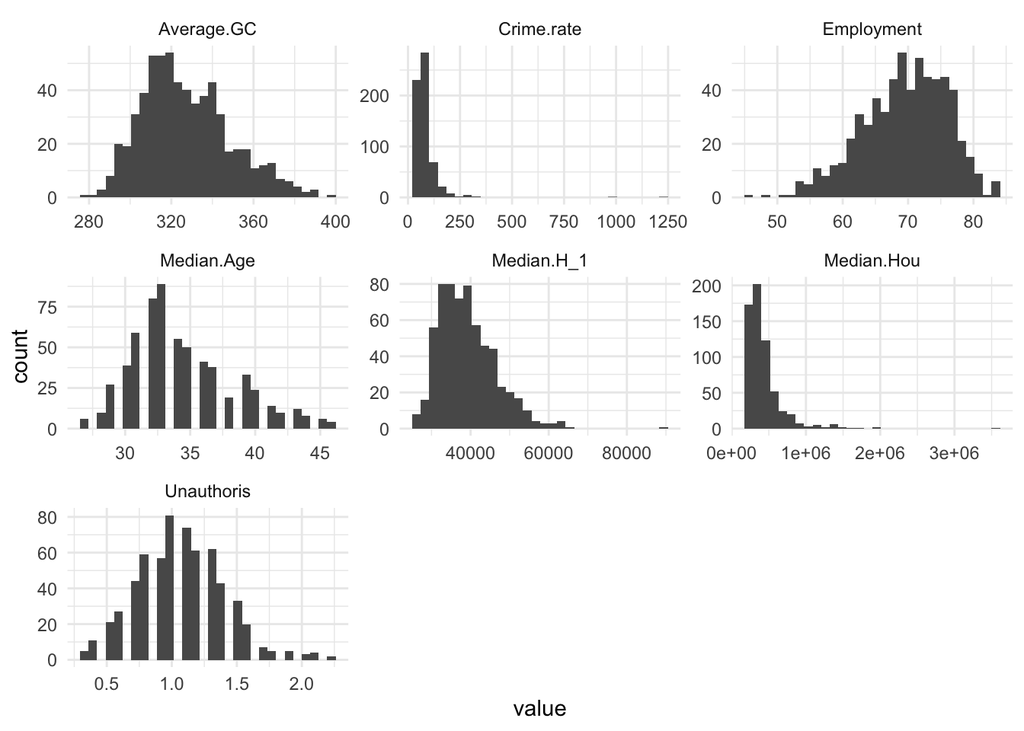

```r
Regressiondata |> as.data.frame() |> select(-geometry, -BOROUGH) |>
  gather(key = 'parameter', value = 'value') |>
ggplot() +
  geom_histogram(aes(x = value)) +
  facet_wrap(.~parameter, scales = 'free')+
  theme_minimal()
```

We can see that some of the variables do not have a normal distribution. We can fix this by transforming the values, for example using a natural logarithm transformation.

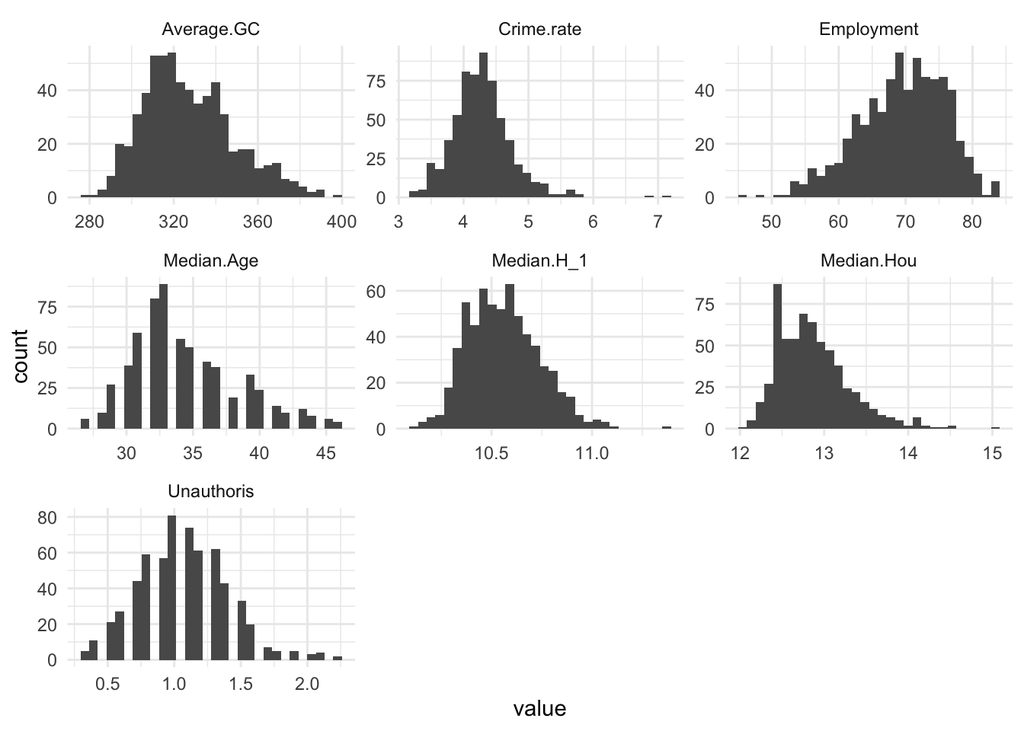

```r
Regressiondata |> as.data.frame() |> select(-geometry, -BOROUGH) |>
  gather(key = 'parameter', value = 'value') |>
  mutate(value = if_else(parameter %in% c('Median.H_1', 'Crime.rate', 'Median.Hou'),
                         log(value),
                         value)) |>
ggplot() +
  geom_histogram(aes(x = value)) +
  facet_wrap(.~parameter, scales = 'free')+
  theme_minimal()
```

Now all possible predictors follow a somewhat normal distribution.

We can also explore co-linearity of the variables with correlation

```r
library(GGally)
```

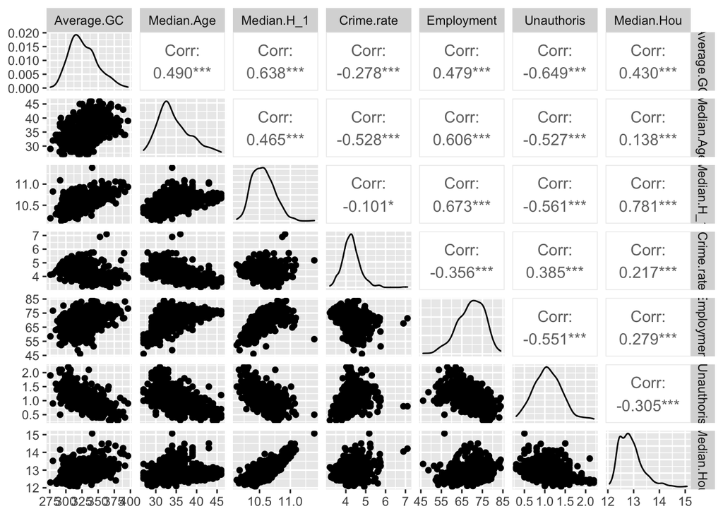

```r
Regressiondata |>
  as.data.frame() |>
  select(-geometry, -BOROUGH) |>
  mutate(Median.H_1 = log(Median.H_1),
         Crime.rate = log(Crime.rate),
         Median.Hou = log(Median.Hou)) |>
  ggpairs()
```

In this case Median.H_1 and Median.Hou, and Median.H_1 and Employment have a high positive correlation, so it would not be recommended to use those variables together.

We are going to add variables to our previous linear model and see which combination explains better the variability of Average GCSE scores.

```r
#now model
model1 <- Regressiondata %>%
  lm(Average.GC ~ Median.Age, data=.)
model2 <- Regressiondata %>%
  lm(Average.GC ~ Median.Age + log(Median.H_1), data=.)
model3 <- Regressiondata %>%
  lm(Average.GC ~ Median.Age + log(Crime.rate), data=.)
model4 <- Regressiondata %>%
  lm(Average.GC ~ Median.Age + Employment, data=.)
model5 <- Regressiondata %>%
  lm(Average.GC ~ Median.Age + Unauthoris, data=.)
model6 <- Regressiondata %>%
  lm(Average.GC ~ Median.Age + log(Median.Hou), data=.)
model7 <- Regressiondata %>%
  lm(Average.GC ~ Median.Age + log(Median.H_1) + Unauthoris, data=.)

#show the summary of those outputs
summary(model1)
```

```
##
## Call:
## lm(formula = Average.GC ~ Median.Age, data = .)
##
## Residuals:
##     Min      1Q  Median      3Q     Max
## -49.708 -12.858  -1.581  11.297  65.628
##
## Coefficients:
##             Estimate Std. Error t value Pr(>|t|)
## (Intercept) 235.1002     6.6227    35.5   <2e-16 ***
## Median.Age    2.6727     0.1909    14.0   <2e-16 ***
## ---
## Signif. codes:  0 '***' 0.001 '**' 0.01 '*' 0.05 '.' 0.1 ' ' 1
##
## Residual standard error: 18.81 on 622 degrees of freedom
## Multiple R-squared:  0.2396, Adjusted R-squared:  0.2384
## F-statistic:   196 on 1 and 622 DF,  p-value: < 2.2e-16
```

```r
summary(model2)
```

```
##
## Call:
## lm(formula = Average.GC ~ Median.Age + log(Median.H_1), data = .)
##
## Residuals:
##     Min      1Q  Median      3Q     Max
## -72.890  -9.579   0.026  10.511  48.779
##
## Coefficients:
##                  Estimate Std. Error t value Pr(>|t|)
## (Intercept)     -384.9631    40.0940  -9.602  < 2e-16 ***
## Median.Age         1.3430     0.1829   7.343 6.59e-13 ***
## log(Median.H_1)   63.0545     4.0370  15.619  < 2e-16 ***
## ---
## Signif. codes:  0 '***' 0.001 '**' 0.01 '*' 0.05 '.' 0.1 ' ' 1
##
## Residual standard error: 15.95 on 621 degrees of freedom
## Multiple R-squared:  0.4541, Adjusted R-squared:  0.4523
## F-statistic: 258.3 on 2 and 621 DF,  p-value: < 2.2e-16
```

```r
summary(model3)
```

```
##
## Call:
## lm(formula = Average.GC ~ Median.Age + log(Crime.rate), data = .)
##
## Residuals:
##     Min      1Q  Median      3Q     Max
## -49.350 -13.022  -1.383  11.346  66.067
##
## Coefficients:
##                 Estimate Std. Error t value Pr(>|t|)
## (Intercept)     243.4281    14.1221  17.237   <2e-16 ***
## Median.Age        2.5935     0.2248  11.536   <2e-16 ***
## log(Crime.rate)  -1.3084     1.9593  -0.668    0.505
## ---
## Signif. codes:  0 '***' 0.001 '**' 0.01 '*' 0.05 '.' 0.1 ' ' 1
##
## Residual standard error: 18.81 on 621 degrees of freedom
## Multiple R-squared:  0.2402, Adjusted R-squared:  0.2377
## F-statistic: 98.15 on 2 and 621 DF,  p-value: < 2.2e-16
```

```r
summary(model4)
```

```
##
## Call:
## lm(formula = Average.GC ~ Median.Age + Employment, data = .)
##
## Residuals:
##     Min      1Q  Median      3Q     Max
## -50.040 -12.212  -1.295  10.385  61.915
##
## Coefficients:
##             Estimate Std. Error t value Pr(>|t|)
## (Intercept) 201.2591     8.1046  24.833  < 2e-16 ***
## Median.Age    1.7186     0.2317   7.417 3.94e-13 ***
## Employment    0.9607     0.1414   6.796 2.52e-11 ***
## ---
## Signif. codes:  0 '***' 0.001 '**' 0.01 '*' 0.05 '.' 0.1 ' ' 1
##
## Residual standard error: 18.16 on 621 degrees of freedom
## Multiple R-squared:  0.2923, Adjusted R-squared:   0.29
## F-statistic: 128.2 on 2 and 621 DF,  p-value: < 2.2e-16
```

```r
summary(model5)
```

```
##
## Call:
## lm(formula = Average.GC ~ Median.Age + Unauthoris, data = .)
##
## Residuals:
##     Min      1Q  Median      3Q     Max
## -58.567  -9.915  -1.016   8.526  61.025
##
## Coefficients:
##             Estimate Std. Error t value Pr(>|t|)
## (Intercept)  325.605      8.116  40.120  < 2e-16 ***
## Median.Age     1.114      0.191   5.833 8.79e-09 ***
## Unauthoris   -34.301      2.216 -15.482  < 2e-16 ***
## ---
## Signif. codes:  0 '***' 0.001 '**' 0.01 '*' 0.05 '.' 0.1 ' ' 1
##
## Residual standard error: 15.99 on 621 degrees of freedom
## Multiple R-squared:  0.4514, Adjusted R-squared:  0.4496
## F-statistic: 255.5 on 2 and 621 DF,  p-value: < 2.2e-16
```

```r
summary(model6)
```

```
##
## Call:
## lm(formula = Average.GC ~ Median.Age + log(Median.Hou), data = .)
##
## Residuals:
##     Min      1Q  Median      3Q     Max
## -65.763 -10.135  -0.214   9.792  58.595
##
## Coefficients:
##                 Estimate Std. Error t value Pr(>|t|)
## (Intercept)       8.1958    20.5906   0.398    0.691
## Median.Age        2.3943     0.1751  13.675   <2e-16 ***
## log(Median.Hou)  18.3775     1.5949  11.523   <2e-16 ***
## ---
## Signif. codes:  0 '***' 0.001 '**' 0.01 '*' 0.05 '.' 0.1 ' ' 1
##
## Residual standard error: 17.08 on 621 degrees of freedom
## Multiple R-squared:  0.3736, Adjusted R-squared:  0.3715
## F-statistic: 185.2 on 2 and 621 DF,  p-value: < 2.2e-16
```

```r
summary(model7)
```

```
##
## Call:
## lm(formula = Average.GC ~ Median.Age + log(Median.H_1) + Unauthoris,
##     data = .)
##
## Residuals:
##     Min      1Q  Median      3Q     Max
## -75.110  -8.750  -0.240   8.153  45.252
##
## Coefficients:
##                  Estimate Std. Error t value Pr(>|t|)
## (Intercept)     -140.2043    43.3067  -3.237 0.001270 **
## Median.Age         0.6388     0.1804   3.542 0.000427 ***
## log(Median.H_1)   44.6179     4.0865  10.918  < 2e-16 ***
## Unauthoris       -24.0509     2.2372 -10.751  < 2e-16 ***
## ---
## Signif. codes:  0 '***' 0.001 '**' 0.01 '*' 0.05 '.' 0.1 ' ' 1
##
## Residual standard error: 14.65 on 620 degrees of freedom
## Multiple R-squared:  0.5399, Adjusted R-squared:  0.5376
## F-statistic: 242.5 on 3 and 620 DF,  p-value: < 2.2e-16
```

Median.Age, Median.H_1 and Unauthoris explain 54% of Average GCSE scores variability.

```r
Regressiondata <- Regressiondata |>
  mutate(residuals = residuals(model7))
```

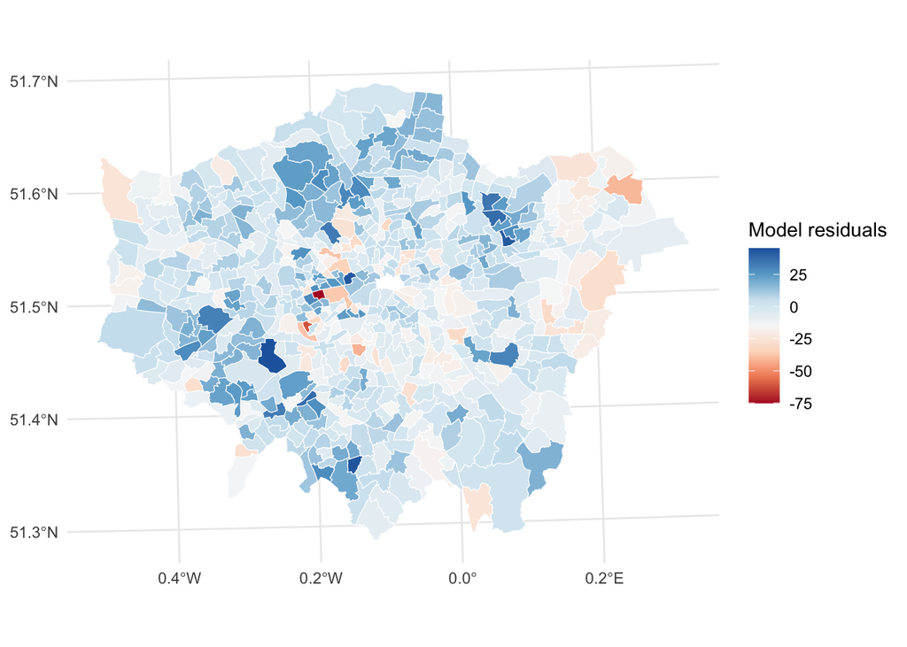

```r
(g1 <- ggplot(Regressiondata) +
  geom_sf(aes(fill = residuals), color = 'white', size = .2) +
  scale_fill_distiller(
  type = "div",
  palette = 5,
  direction = 1,
  aesthetics = "fill"
) +
  coord_sf() +
  theme_minimal() +
  labs(fill = 'Model residuals')
)
```

```r
library(spatialreg)
library(spdep)

knn <- st_geometry(Regressiondata) %>%
  st_centroid() %>%
  knearneigh(., k=4) %>%
  knn2nb()

lw <- nb2listw(knn, style="W", zero.policy=TRUE)
slag_model2_queen <- lagsarlm(Average.GC ~ Median.Age + log(Median.H_1) + Unauthoris,
                              data = Regressiondata,
                              lw, method = "eigen")
```

```r
moran.mc(Regressiondata$residuals, lw, nsim=9999, alternative="greater")
```

```
##
##  Monte-Carlo simulation of Moran I
##
## data:  Regressiondata$residuals
## weights: lw
## number of simulations + 1: 10000
##
## statistic = 0.27301, observed rank = 10000, p-value = 1e-04
## alternative hypothesis: greater
```

Moran’s Index was calculated to test for spatial autocorrelation of the residuals. Now we are going to introduce a spatial lag term to the equation.

```r
broom::tidy(slag_model2_queen)
```

```
## # A tibble: 5 × 5
##   term            estimate std.error statistic  p.value
##   <chr>              <dbl>     <dbl>     <dbl>    <dbl>
## 1 rho                0.316    0.0417      7.58 3.46e-14
## 2 (Intercept)     -152.      40.9        -3.71 2.07e- 4
## 3 Median.Age         0.402    0.173       2.32 2.01e- 2
## 4 log(Median.H_1)   36.3      4.08        8.90 0
## 5 Unauthoris       -20.2      2.17       -9.31 0
```

```r
summary(slag_model2_queen)
```

```
##
## Call:lagsarlm(formula = Average.GC ~ Median.Age + log(Median.H_1) +
##     Unauthoris, data = Regressiondata, listw = lw, method = "eigen")
##
## Residuals:
##       Min        1Q    Median        3Q       Max
## -81.12453  -8.33145   0.11959   8.28277  48.58225
##
## Type: lag
## Coefficients: (asymptotic standard errors)
##                   Estimate Std. Error z value  Pr(>|z|)
## (Intercept)     -151.59801   40.85440 -3.7107 0.0002067
## Median.Age         0.40219    0.17304  2.3242 0.0201154
## log(Median.H_1)   36.28783    4.07913  8.8960 < 2.2e-16
## Unauthoris       -20.21857    2.17080 -9.3139 < 2.2e-16
##
## Rho: 0.31589, LR test value: 55.358, p-value: 1.0048e-13
## Asymptotic standard error: 0.041674
##     z-value: 7.58, p-value: 3.4639e-14
## Wald statistic: 57.457, p-value: 3.4528e-14
##
## Log likelihood: -2530.958 for lag model
## ML residual variance (sigma squared): 190.96, (sigma: 13.819)
## Number of observations: 624
## Number of parameters estimated: 6
## AIC: 5073.9, (AIC for lm: 5127.3)
## LM test for residual autocorrelation
## test value: 16.179, p-value: 5.7631e-05
```

```r
Regressiondata <- Regressiondata |>
  mutate(residuals_spatial = residuals(slag_model2_queen))

moran.mc(Regressiondata$residuals_spatial, lw, nsim=9999, alternative="greater")
```

```
##
##  Monte-Carlo simulation of Moran I
##
## data:  Regressiondata$residuals_spatial
## weights: lw
## number of simulations + 1: 10000
##
## statistic = 0.065256, observed rank = 9908, p-value = 0.0092
## alternative hypothesis: greater
```

By compensating for the spatial variability, Moran’s I was reduced significantly.

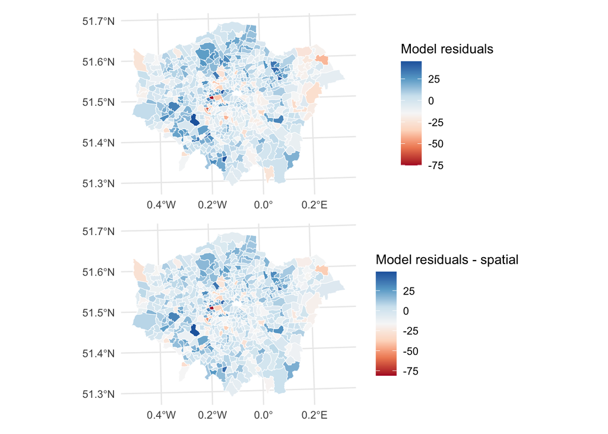

```r
g2 <- ggplot(Regressiondata) +
  geom_sf(aes(fill = residuals_spatial), color = 'white', size = .2) +
  scale_fill_distiller(
  type = "div",
  palette = 5,
  direction = 1,
  aesthetics = "fill"
) +
  coord_sf() +
  theme_minimal() +
  labs(fill = 'Model residuals - spatial')

g1 / g2
```

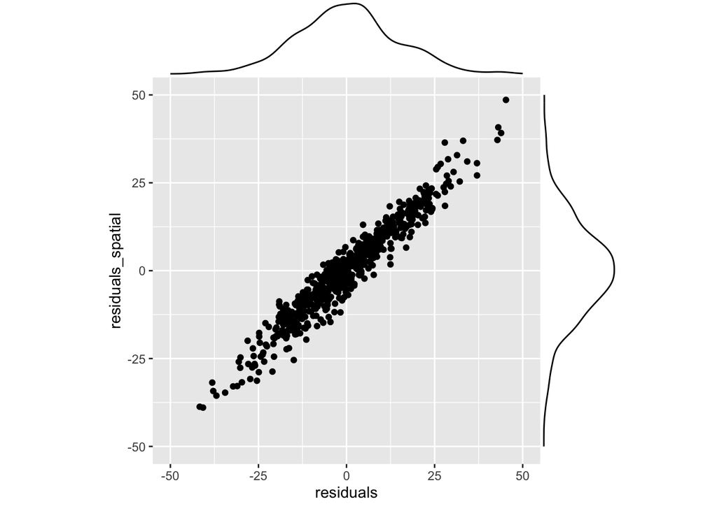

```r
library(ggExtra)

g <- Regressiondata |>
  ggplot() +
  geom_point(aes(x = residuals, y = residuals_spatial)) +
  xlim(-50, 50) +
  ylim(-50, 50) +
  coord_equal()

g1 <- ggMarginal(g, type="density")
g1
```

Model residuals for both, multiple linear regression with and without the spatial term, have a normal distribution.